# —————— Introducción a R - Manejar Datos ——————

# 1. Objetivos de Aprendizaje

Al final de este taller usted podrá saber cómo:

- Agrupar y resumir datos usando el paquete “dplyr”
- Usar las funciones mutate(), filter(), select(), group(), y summarise() del paquete “dplyr” para modificar estructuras de datos
- Usar la funciones group() y summarise() para analizar estructuras de datos
- Cargar datos en varios formatos
- Usar las funciones pivot_longer() y pivot_wider() del paquete “tidyr” para modificar la disposición de estructuras de datos
- Usar las funciones str_replace() y str_remove() del paquete “stringr” para manipular caracteres en estructuras de datos

# 2. Para Empezar

**Que es necesario para limpiar datos en R y por que es importante?**

Ahora que aprendimos como visualizar datos, vamos hablar sobre unos paquetes y funciones necesarios para manejar datos, que fueron útil en crear visuales interesantes en el taller previo. Anteriormente, hablamos sobre la importancia de crear gráficos que resonaría con tu audiencia y reflejen tu mensaje deseado. Ahora que sabemos como cumplir esto, es importante aprender manipular datos para reflejar nuestro mensaje deseado.

Datos vienen en muchos tipos de formas y lo que es útil o practico para una aplicación no necesariamente trabajaría para otra. R tiene requisitos específicos sobre la configuración y los tipos de datos que se pueden pasar entre las funciones. Entonces, es muy importante tener la habilidad de manipular tus datos y darles la forma necesaria. Unas de las funciones que hablaremos sobre en este taller tienen el poder de manipular estructuras de datos en forma de filtrar, reorganizar, y acomodar caracteres.

**¿Qué es necesario para manipular datos en R?**

Ahora, vamos a instalar los paquetes que vamos a usar en este taller. Para empezar, vamos a instalar los paquetes, “dplyr”, “tidyr”, y “stringr”. Solamente es necesario hacer esto una vez porque los paquetes automáticamente serian guardados en la sección, “Packages”, en RStudio. Los paquete te da acceso a todas las funciones creadas por el usuario y pueden ser instalados usando la linea de código siguiente:

```r
install.packages('dplyr')
install.packages('tidyr')
install.packages('stringr')
```

Cuando los paquetes terminen de instalarse, aparecería un mensaje indicando que los paquetes fueron instalados con éxito!

# 3. Paquetes para crear graficos

# 3.1 dplyr

Dplyr es un paquete útil para reorganizar, modificar, y manipular datos. Es posible que usarías este paquete frecuentemente en el laboratorio. Por favor carga este paquete en R usando`library()`. Ahora, vamos hablar de cinco funciones especificas en el paquete, “dplyr” : `filter()`,`mutate()`, `select()` , `group_by()`, y `summarise()`.

**Tips!**

Recuerda que cada vez que abres R de nuevo y deseas usar el paquete,`dplyr()`, tienes que cargar el paquete usando la función `library()`

```r
library(dplyr)
library(tidyr)
library(stringr)
library(ggplot2)
```

En preparación para los ejemplos siguientes, por favor carga los datos “ATLANTIC_BUTTERFLIES_sites.csv” en R en un objeto con el nombre “butterfly”.

```r
butterfly <- read.csv2("ATLANTIC_BUTTERFLIES_sites.csv")
```

En las siguientes lineas de código en este taller, las funciones no modificaran las estructuras de datos permanentemente por el propósito de los ejemplos instructivos. Para guardar las modificaciones del estructura de datos, uno debería asignar la función a un objeto.

Compara los dos ejemplos de código siguientes y pon atención a cual código modifica el estructura de datos y se encuentra en el “environment”:

**Codigo 1**

```r
filter(butterfly, sites_ID == "bor1122")
```

| sites_ID | Country | State | Municipality | Study.Location | Latitude | Longitude | Precision | Reserve_Area | Altitude | Altitude1km | A_mean_temp | A_rainfall | Olsong200r | Olsoneconame | Ribeirovegtype | BSRs |
| --- | --- | --- | --- | --- | --- | --- | --- | --- | --- | --- | --- | --- | --- | --- | --- | --- |
| bor1122 | Brazil | BAHIA | CRUZ DAS ALMAS | Campus da Universidade Federal do Reconcavo Baiano | -12.65 | -39.11666667 | Not Precise | NA | 220 | 139 | 23.14 | 1078 | Atlantic Forests | Bahia interior forests | Floresta Estacional Semidecidual | Diamantina |

**Codigo 2**

```r
butterfly_modified <- filter(butterfly, sites_ID == "bor1120")
```

# 3.2 dplyr: filter - filtrando datos basado en criteros

Una de las funciones dplyr mas util es `filter()`. Con esta función, es posible filtrar observaciones especificas basado en las entradas en una o mas columnas.

Ahora vamos a explorar el estructura de datos “butterfly” en mas detalle. Puedemos abrir el estructura usando la función`view()` or con hacer clic en “butterfly” en el panel de “data”. Aquí podemos ver que la columna “numero de sitio” (sites_ID) tiene varios diferentes tipos de “números de sitios” (sites_ID). Que pasa si queríamos crear una estructura de datos que solamente incluye las observaciones del sitio “bor1001”? Esto es cuando utilizáramos la función `filter()` en la siguiente linea de código:

```r
filter(butterfly, sites_ID == "bor1001")
```

| sites_ID | Country | State | Municipality | Study.Location | Latitude | Longitude | Precision | Reserve_Area | Altitude | Altitude1km | A_mean_temp | A_rainfall | Olsong200r | Olsoneconame | Ribeirovegtype | BSRs |
| --- | --- | --- | --- | --- | --- | --- | --- | --- | --- | --- | --- | --- | --- | --- | --- | --- |
| bor1001 | Brazil | RIO GRANDE DO SUL | MAQUINE | Maquine | -29.58333333 | -50.26666667 | 13000 | NA | 100-300 | 305 | 18.68 | 1568 | Atlantic Forests | Araucaria moist forests | Floresta Ombrofila Mista | Florestas de Araucaria |

Ademas, es posible a filtrar observaciones numéricamente. Por ejemplo, para obtener una estructura de datos que contiene todos los sitios donde callo mas de 1000 mm de lluvia, utilizáramos la siguiente linea de código. Pon atención que cuando filtras por numero, no es necesario poner comillas en el numero.

```r
filter(butterfly, A_rainfall >= 1000)
```

| sites_ID | Country | State | Municipality | Study.Location | Latitude | Longitude | Precision | Reserve_Area | Altitude | Altitude1km | A_mean_temp | A_rainfall | Olsong200r | Olsoneconame | Ribeirovegtype | BSRs |
| --- | --- | --- | --- | --- | --- | --- | --- | --- | --- | --- | --- | --- | --- | --- | --- | --- |
| bor1001 | Brazil | RIO GRANDE DO SUL | MAQUINE | Maquine | -29.58333333 | -50.26666667 | 13000 | NA | 100-300 | 305 | 18.68 | 1568 | Atlantic Forests | Araucaria moist forests | Floresta Ombrofila Mista | Florestas de Araucaria |
| bor1002 | Brazil | RIO GRANDE DO SUL | SAO FRANCISCO DE PAULA | Floresta Nacional de Sao Francisco de Paula | -29.423669 | -50.386914 | 2200 | 1615 | 900 | 917 | 14.94 | 2083 | Atlantic Forests | Araucaria moist forests | Estepe | Florestas de Araucaria |
| bor1003 | Brazil | RIO GRANDE DO SUL | SANTA MARIA | Santa Maria | -29.747514 | -53.838197 | 30 | NA | 50-100 | 99 | 19.86 | 1665 | NA | Uruguayan savanna | Areas de Tensao Ecologica | Florestas de Interior |
| bor1004 | Brazil | PARANA | CURITIBA | Curitiba | -25.3 | -49.36666667 | 12000 | NA | 850-1000 | 956 | 16.69 | 1641 | Atlantic Forests | Araucaria moist forests | Floresta Ombrofila Mista | Florestas de Araucaria |
| bor1005 | Brazil | PARANA | LONDRINA | Londrina | -23.306445 | -51.170618 | Not Precise | NA | 500-600 | 571 | 20.65 | 1598 | Atlantic Forests | Alto Parana Atlantic forests | Floresta Estacional Semidecidual | Florestas de Interior |

Finalmente, es posible usar un infinito numero de observaciones para filtrar el estructura de datos, todo dentro la misma linea de código. Por ejemplo, si querías crear una estructura de datos conteniendo solamente sitios en Rio De Jainero donde callo mas de 1000 mm de lluvia, usarías esta linea de código:

```r
filter(butterfly, State == "RIO DE JANEIRO", A_rainfall >= 1000)
```

| sites_ID | Country | State | Municipality | Study.Location | Latitude | Longitude | Precision | Reserve_Area | Altitude | Altitude1km | A_mean_temp | A_rainfall | Olsong200r | Olsoneconame | Ribeirovegtype | BSRs |
| --- | --- | --- | --- | --- | --- | --- | --- | --- | --- | --- | --- | --- | --- | --- | --- | --- |
| bor1018 | Brazil | RIO DE JANEIRO | ITATIAIA | Paque Nacional do Itatiaia | -22.375278 | -44.662222 | 9000 | 28086.06751 | 2000-2600 | 2534 | 9.39 | 2300 | Atlantic Forests | Campos Rupestres montane savanna | Floresta Ombrofila Densa | Florestas de Interior |
| bor1019 | Brazil | RIO DE JANEIRO | GUAPIMIRIM | Guapimirim | -22.49305556 | -42.94916667 | 30 | NA | 50-250 | 305 | 22 | 1441 | Atlantic Forests | Serra do Mar coastal forests | Floresta Ombrofila Densa | Serra do Mar |
| bor1020 | Brazil | RIO DE JANEIRO | CACHOEIRAS DE MACACU | Reserva Ecologica de Guapiacu | -22.45388889 | -42.77166667 | 30 | 7.385 | 30-180 | 120 | 22.85 | 1284 | Atlantic Forests | Serra do Mar coastal forests | Floresta Ombrofila Densa | Serra do Mar |
| bor1021 | Brazil | RIO DE JANEIRO | CACHOEIRAS DE MACACU | Boca do Mato | -22.40583333 | -42.60694444 | 30 | NA | 200-450 | 488 | 20.28 | 1277 | Atlantic Forests | Serra do Mar coastal forests | Floresta Ombrofila Densa | Serra do Mar |
| bor1022 | Brazil | RIO DE JANEIRO | PETROPOLIS | Independencia and Alto Xerem and Petropolis | -22.54416667 | -43.20472222 | 30 | NA | 900-1000 | 592 | 18.38 | 1867 | Atlantic Forests | Serra do Mar coastal forests | Floresta Ombrofila Densa | Serra do Mar |

**Información!**

La función `filter()` filtrara por la orden que los elementos son listados en la función. Por ejemplo, para la linea de código previo, R filtrara por “estado” (State) y luego por “cantidad de lluvia” (A_rainfall) . Con esta información, pon atención a la orden de los elementos para filtrar tus datos en la manera que deseas.

# 3.3 dplyr: select() - modificando estructaras de datos basado en nombre de columna

Otra función importante es la función `select()`. Esta función es similar a la función del símbolo, “$”, porque las dos funciones te dejan examinar una parte especifica del estructura de datos. Esta función is particularmente útil cuando uno anda manipulando estructuras de datos vasto. Específicamente, la función `select()` te deja dividir una o mas columnas de tu estructura de datos y transferir los a una nueva estructura de datos.

Por ejemplo, imagine que querías crear una estructura de datos conteniendo solamente las columnas “numero de sitio” (sites_ID) y “estado” (State) de la original estructura de datos, “butterfly”. Puedes completar este comande usando la siguiente linea de código:

```r
select(butterfly,sites_ID, State)
```

| sites_ID | State |
| --- | --- |
| bor1001 | RIO GRANDE DO SUL |
| bor1002 | RIO GRANDE DO SUL |
| bor1003 | RIO GRANDE DO SUL |
| bor1004 | PARANA |
| bor1005 | PARANA |

**Información!**

Las diferentes columnas que seleccionaste están dividas entre comas y los nombres de las columnas tienen que tener los mismos nombres de la estructura de datos original (esto incluye el uso de mayúsculas, espacios, guiones,periodos, etc).

Si planillas a crear una estructura de datos que contiene la mayoría de columnas de la estructura original, puede ser tedioso a listar todos los nombres de las columnas. Afortunadamente, la función `select()` permite quitar columnas usando el símbolo “-”. Ahora, imagine que queremos a crear una estructura de datos que contiene todas las columnas de la original “butterfly” estructura excluyendo “numero de sitio” (sites_ID) y “estado” (State) utilizáramos la siguiente linea de código:

```r
select(butterfly,-sites_ID, -State)
```

| Country | Municipality | Study.Location | Latitude | Longitude | Precision | Reserve_Area | Altitude | Altitude1km | A_mean_temp | A_rainfall | Olsong200r | Olsoneconame | Ribeirovegtype | BSRs |
| --- | --- | --- | --- | --- | --- | --- | --- | --- | --- | --- | --- | --- | --- | --- |
| Brazil | MAQUINE | Maquine | -29.58333333 | -50.26666667 | 13000 | NA | 100-300 | 305 | 18.68 | 1568 | Atlantic Forests | Araucaria moist forests | Floresta Ombrofila Mista | Florestas de Araucaria |
| Brazil | SAO FRANCISCO DE PAULA | Floresta Nacional de Sao Francisco de Paula | -29.423669 | -50.386914 | 2200 | 1615 | 900 | 917 | 14.94 | 2083 | Atlantic Forests | Araucaria moist forests | Estepe | Florestas de Araucaria |
| Brazil | SANTA MARIA | Santa Maria | -29.747514 | -53.838197 | 30 | NA | 50-100 | 99 | 19.86 | 1665 | NA | Uruguayan savanna | Areas de Tensao Ecologica | Florestas de Interior |
| Brazil | CURITIBA | Curitiba | -25.3 | -49.36666667 | 12000 | NA | 850-1000 | 956 | 16.69 | 1641 | Atlantic Forests | Araucaria moist forests | Floresta Ombrofila Mista | Florestas de Araucaria |
| Brazil | LONDRINA | Londrina | -23.306445 | -51.170618 | Not Precise | NA | 500-600 | 571 | 20.65 | 1598 | Atlantic Forests | Alto Parana Atlantic forests | Floresta Estacional Semidecidual | Florestas de Interior |

```r
select(butterfly, sites_ID:Altitude)
```

| sites_ID | Country | State | Municipality | Study.Location | Latitude | Longitude | Precision | Reserve_Area | Altitude |
| --- | --- | --- | --- | --- | --- | --- | --- | --- | --- |
| bor1001 | Brazil | RIO GRANDE DO SUL | MAQUINE | Maquine | -29.58333333 | -50.26666667 | 13000 | NA | 100-300 |
| bor1002 | Brazil | RIO GRANDE DO SUL | SAO FRANCISCO DE PAULA | Floresta Nacional de Sao Francisco de Paula | -29.423669 | -50.386914 | 2200 | 1615 | 900 |
| bor1003 | Brazil | RIO GRANDE DO SUL | SANTA MARIA | Santa Maria | -29.747514 | -53.838197 | 30 | NA | 50-100 |
| bor1004 | Brazil | PARANA | CURITIBA | Curitiba | -25.3 | -49.36666667 | 12000 | NA | 850-1000 |
| bor1005 | Brazil | PARANA | LONDRINA | Londrina | -23.306445 | -51.170618 | Not Precise | NA | 500-600 |

# 3.4 dplyr: mutate - agregando columnas a estructuras de datos

La función `mutate()` esta utilizada para agregar columnas a una estructura de datos que ya existe. La nueva columna usualmente es una función de uno o mas de las columnas existentes. Por ejemplo, imagina que querías añadir una columna a la estructura “butterfly” igual a el logaritmo de la columna “A_rainfall”. Esta acción puede ser completada en dos maneras.

Primero, puedes crear una nueva estructura de datos que incluye todas las columnas encontradas en el estructura original de “butterfly”, con la nueva adición. Esto es similar a los ejemplos previos con `filter()` y `select()`:

```r
mutate(butterfly, Log_Rainfall = log(A_rainfall))
```

| sites_ID | Country | State | Municipality | Study.Location | Latitude | Longitude | Precision | Reserve_Area | Altitude | Altitude1km | A_mean_temp | A_rainfall | Olsong200r | Olsoneconame | Ribeirovegtype | BSRs | Log_Rainfall |
| --- | --- | --- | --- | --- | --- | --- | --- | --- | --- | --- | --- | --- | --- | --- | --- | --- | --- |
| bor1001 | Brazil | RIO GRANDE DO SUL | MAQUINE | Maquine | -29.58333333 | -50.26666667 | 13000 | NA | 100-300 | 305 | 18.68 | 1568 | Atlantic Forests | Araucaria moist forests | Floresta Ombrofila Mista | Florestas de Araucaria | 7.357556 |
| bor1002 | Brazil | RIO GRANDE DO SUL | SAO FRANCISCO DE PAULA | Floresta Nacional de Sao Francisco de Paula | -29.423669 | -50.386914 | 2200 | 1615 | 900 | 917 | 14.94 | 2083 | Atlantic Forests | Araucaria moist forests | Estepe | Florestas de Araucaria | 7.641564 |
| bor1003 | Brazil | RIO GRANDE DO SUL | SANTA MARIA | Santa Maria | -29.747514 | -53.838197 | 30 | NA | 50-100 | 99 | 19.86 | 1665 | NA | Uruguayan savanna | Areas de Tensao Ecologica | Florestas de Interior | 7.417580 |
| bor1004 | Brazil | PARANA | CURITIBA | Curitiba | -25.3 | -49.36666667 | 12000 | NA | 850-1000 | 956 | 16.69 | 1641 | Atlantic Forests | Araucaria moist forests | Floresta Ombrofila Mista | Florestas de Araucaria | 7.403061 |
| bor1005 | Brazil | PARANA | LONDRINA | Londrina | -23.306445 | -51.170618 | Not Precise | NA | 500-600 | 571 | 20.65 | 1598 | Atlantic Forests | Alto Parana Atlantic forests | Floresta Estacional Semidecidual | Florestas de Interior | 7.376508 |

Tambien es posible a añadir mas de una columna a una estructura de datos usando la linea de código:

```r
mutate(butterfly, Log_Rainfall = log(A_rainfall), climate_index = A_mean_temp * A_rainfall)
```

En esta linea de código, añadimos dos columnas, la columna previa que toma el logaritmo de la columna “A_rainfall” y una nueva columna, “climate_index”, que calcula el indice de clima con multiplicar las columnas “A_rainfall” y “A_mean_temp”.

**Que pasa cuando ejecutas la linea de codigo previa?**

R indica que hay un error en calcular la indice de clima porque la columna de temperatura, “A_mean_temp”, no es un numérico.

Para examinar la estructura del estructura de datos, “butterfly”, recuerda que es posible utilizar la función `str()`:

```r
str(butterfly)
```

```
## 'data.frame':    122 obs. of  17 variables:
##  $ sites_ID      : chr  "bor1001" "bor1002" "bor1003" "bor1004" ...
##  $ Country       : chr  "Brazil" "Brazil" "Brazil" "Brazil" ...
##  $ State         : chr  "RIO GRANDE DO SUL" "RIO GRANDE DO SUL" "RIO GRANDE DO SUL" "PARANA" ...
##  $ Municipality  : chr  "MAQUINE" "SAO FRANCISCO DE PAULA" "SANTA MARIA" "CURITIBA" ...
##  $ Study.Location: chr  "Maquine" "Floresta Nacional de Sao Francisco de Paula" "Santa Maria" "Curitiba" ...
##  $ Latitude      : chr  "-29.58333333" "-29.423669" "-29.747514" "-25.3" ...
##  $ Longitude     : chr  "-50.26666667" "-50.386914" "-53.838197" "-49.36666667" ...
##  $ Precision     : chr  "13000" "2200" "30" "12000" ...
##  $ Reserve_Area  : chr  NA "1615" NA NA ...
##  $ Altitude      : chr  "100-300" "900" "50-100" "850-1000" ...
##  $ Altitude1km   : int  305 917 99 956 571 936 442 280 139 803 ...
##  $ A_mean_temp   : chr  "18.68" "14.94" "19.86" "16.69" ...
##  $ A_rainfall    : int  1568 2083 1665 1641 1598 1691 1256 1202 1763 1431 ...
##  $ Olsong200r    : chr  "Atlantic Forests" "Atlantic Forests" NA "Atlantic Forests" ...
##  $ Olsoneconame  : chr  "Araucaria moist forests" "Araucaria moist forests" "Uruguayan savanna" "Araucaria moist forests" ...
##  $ Ribeirovegtype: chr  "Floresta Ombrofila Mista" "Estepe" "Areas de Tensao Ecologica" "Floresta Ombrofila Mista" ...
##  $ BSRs          : chr  "Florestas de Araucaria" "Florestas de Araucaria" "Florestas de Interior" "Florestas de Araucaria" ...
```

Con usar la función `str()` se puede confirmar que la columna, “A_mean_temp”, esta clasificado como un carácter en vez de numérico.

Entonces, para realizar la operación de multiplicación en calculando la indice de clima, deberíamos cambiar la columna, “A_mean_temp”, a la forma numérica usando la linea de código siguiente:

```r
butterfly <- mutate(butterfly, A_mean_temp = as.numeric(A_mean_temp))

mutate(butterfly, Log_Rainfall = log(A_rainfall), climate_index = A_mean_temp * A_rainfall)
```

| sites_ID | Country | State | Municipality | Study.Location | Latitude | Longitude | Precision | Reserve_Area | Altitude | Altitude1km | A_mean_temp | A_rainfall | Olsong200r | Olsoneconame | Ribeirovegtype | BSRs | Log_Rainfall | climate_index |
| --- | --- | --- | --- | --- | --- | --- | --- | --- | --- | --- | --- | --- | --- | --- | --- | --- | --- | --- |
| bor1001 | Brazil | RIO GRANDE DO SUL | MAQUINE | Maquine | -29.58333333 | -50.26666667 | 13000 | NA | 100-300 | 305 | 18.68 | 1568 | Atlantic Forests | Araucaria moist forests | Floresta Ombrofila Mista | Florestas de Araucaria | 7.357556 | 29290.24 |
| bor1002 | Brazil | RIO GRANDE DO SUL | SAO FRANCISCO DE PAULA | Floresta Nacional de Sao Francisco de Paula | -29.423669 | -50.386914 | 2200 | 1615 | 900 | 917 | 14.94 | 2083 | Atlantic Forests | Araucaria moist forests | Estepe | Florestas de Araucaria | 7.641564 | 31120.02 |
| bor1003 | Brazil | RIO GRANDE DO SUL | SANTA MARIA | Santa Maria | -29.747514 | -53.838197 | 30 | NA | 50-100 | 99 | 19.86 | 1665 | NA | Uruguayan savanna | Areas de Tensao Ecologica | Florestas de Interior | 7.417580 | 33066.90 |
| bor1004 | Brazil | PARANA | CURITIBA | Curitiba | -25.3 | -49.36666667 | 12000 | NA | 850-1000 | 956 | 16.69 | 1641 | Atlantic Forests | Araucaria moist forests | Floresta Ombrofila Mista | Florestas de Araucaria | 7.403061 | 27388.29 |
| bor1005 | Brazil | PARANA | LONDRINA | Londrina | -23.306445 | -51.170618 | Not Precise | NA | 500-600 | 571 | 20.65 | 1598 | Atlantic Forests | Alto Parana Atlantic forests | Floresta Estacional Semidecidual | Florestas de Interior | 7.376508 | 32998.70 |

Aquí, estamos forzados a crear una nueva estructura de datos en orden de agregar dos (o mas) columnas separadas a la estructura.

# 3.5 dplyr: group_by - categorizando un estructura de datos por nombre de columnas

Vamos a continuar a explorar mas funciones del paquete `dplyr()`. Ahora vamos a utilizar la función, `group_by()`. Esta función es útil cuando tienes dos variables categóricos y quieres analizar cuantos de cada grupo están en una o otra categoría. Esta función crea un estructura de datos que reorganiza el estructura de datos original basado en columnas particulares.

Esta función es mas útil usado con la función `summarise()`, que aprenderemos mas sobre en la sección siguiente.

```r
Grouped_Sites <- group_by(butterfly, sites_ID)
Grouped_Sites
```

```
## # A tibble: 122 × 17
## # Groups:   sites_ID [122]
##    sites_ID Country State         Municipality Study.Location Latitude Longitude
##    <chr>    <chr>   <chr>         <chr>        <chr>          <chr>    <chr>
##  1 bor1001  Brazil  RIO GRANDE D… MAQUINE      Maquine        -29.583… -50.2666…
##  2 bor1002  Brazil  RIO GRANDE D… SAO FRANCIS… Floresta Naci… -29.423… -50.3869…
##  3 bor1003  Brazil  RIO GRANDE D… SANTA MARIA  Santa Maria    -29.747… -53.8381…
##  4 bor1004  Brazil  PARANA        CURITIBA     Curitiba       -25.3    -49.3666…
##  5 bor1005  Brazil  PARANA        LONDRINA     Londrina       -23.306… -51.1706…
##  6 bor1006  Brazil  PARANA        GUARAPUAVA   Guarapuava     -25.402… -51.4211…
##  7 bor1007  Brazil  PARANA        MARINGA      Maringa        -23.435… -51.9430…
##  8 bor1008  Brazil  PARANA        DIAMANTE DO… Estacao Ecolo… -22.618… -52.8566…
##  9 bor1009  Brazil  RIO GRANDE D… PORTO MAUA   Porto Maua     -27.516… -54.6666…
## 10 bor1010  Brazil  PARANA        BALSA NOVA   Sao Luiz do P… -25.760… -50.1777…
## # … with 112 more rows, and 10 more variables: Precision <chr>,
## #   Reserve_Area <chr>, Altitude <chr>, Altitude1km <int>, A_mean_temp <dbl>,
## #   A_rainfall <int>, Olsong200r <chr>, Olsoneconame <chr>,
## #   Ribeirovegtype <chr>, BSRs <chr>
```

Mirando los resultados de la función `group_by()` veras que la estructura de datos ahora esta organizado por categoría pero todavía se ve muy similar al estructura original.

# 3.6 dplyr: summarise - agregando columnas sumadas a estructuras de datos

Ahora, regresaremos a la funcion `summarise()` que mencionamos en la sección previa. Esta función calcula un estadístico especifico en las columnas indicados en tu linea de código y guarda estos valores en una nueva columna que esta agregado a tu estructura de datos. Cuando las funciones `summarise()` y `group_by()` están utilizados juntos, la estadística esta calculado para cada grupo. Por ejemplo, vamos a contar el numero de ocurrencias en cada grupo en nuestro estructura de datos, “butterfly” usando la función `n()`

```r
summarise(Grouped_Sites, n())
```

| sites_ID | n() |
| --- | --- |
| bor1001 | 1 |
| bor1002 | 1 |
| bor1003 | 1 |
| bor1004 | 1 |
| bor1005 | 1 |

## 4. tidyr

Asimismo, tidyr es otro paquete que puede ayudar el usuario a manipular un estructura de datos. El paquete tidyr específicamente es útil para manipular un estructura de datos entre un estructura larga a un estructura ancho y el inverso.

**Información!**

Pero por que es importante manipular un estructura de datos en esta manera? Los paquetes `ggplot()`y `ggplot2()` que usamos en el taller previo para crear gráficos, prefieren visualizar un estructura de datos de la forma larga en vez de ancho.

Recuerda que cada vez que abres R de nuevo y deseas usar el paquete,`tidyr()`, tienes que cargar el paquete usando la función `library()`:

```r
library(tidyr)
```

# 4.1 tidyr: pivot_longer - modificando estructuras de datos a forma larga

La primera función importante del paquete tidyr es ‘pivot_longer()’. Esta función cambia el formato de un estructura de datos, aumentando el numero de filas y reduciendo el numero de columnas, creando un estructura de datos del formato larga.

Vamos a utilizar el estructura de datos sin modificacion, “polar”, del taller previo para explorar esta función. Recuerda cargar el estructura de datos usando la linea siguiente:

```r
polar <- read.delim("ANT-XXVIII_5_seabirds_marine_mammals.tab", skip = 154)
```

Para manipular el estructura de datos, “polar”, a forma larga es posible utilizar la linea de código siguiente:

```r
polar_longer <- pivot_longer(polar, names_to = 'species', values_to = 'abundance', `E..chrysocome......Rockhopper.penguin.`:`Mola.mola......Sun.fish.`)
polar_longer
```

| ID..Consecutive.number.of.transec…. | Date.Time..Starting.time..UTC..of.30.min…. | Latitude..Mid.latitude.of.30.min.transe…. | Longitude..Mid.longitude.of.30.min.trans…. | Bathy.depth..m…Mid.mean.water.depth.of.30.mi…. | Speed..kn…Average.speed.of.the.vessel.d…. | Distance..km…Distance.covered.during.30.mi…. | Sal..Mid.mean.surface.salinity.of….. | Temp…C…Mid.mean.surface.water.temper…. | F.chl..µg.l…Mid.fluorescence.of.30.min.tr…. | Zone..Zones..which.were.defined.on….. | species | abundance |
| --- | --- | --- | --- | --- | --- | --- | --- | --- | --- | --- | --- | --- |
| 1 | 2012-04-11T13:30 | -51.48 | -66.86 | 108 | 8.8 | 8.1488 | 32.9347 | 8.386 | 5.35 | 10 | E..chrysocome……Rockhopper.penguin. | 0 |
| 1 | 2012-04-11T13:30 | -51.48 | -66.86 | 108 | 8.8 | 8.1488 | 32.9347 | 8.386 | 5.35 | 10 | S..magellanicus……Magellanic.penguin. | 0 |
| 1 | 2012-04-11T13:30 | -51.48 | -66.86 | 108 | 8.8 | 8.1488 | 32.9347 | 8.386 | 5.35 | 10 | Penguins……Penguin.sp.. | 0 |
| 1 | 2012-04-11T13:30 | -51.48 | -66.86 | 108 | 8.8 | 8.1488 | 32.9347 | 8.386 | 5.35 | 10 | T..melanophris……Black.browed.albatross. | 16 |
| 1 | 2012-04-11T13:30 | -51.48 | -66.86 | 108 | 8.8 | 8.1488 | 32.9347 | 8.386 | 5.35 | 10 | T..cauta……Shy.albatross. | 0 |

# 4.2 tidyr: pivot_wider - modificando estructuras de datos a forma ancho

La segunda función que hablaremos sobre es el inverso de la primera función. El inverso a `pivot_longer` es `pivot_wider`. Esta función manipula el estructura de datos al formato ancho con aumentar el numero de columnas y reduciendo el numero de filas.

Para manipular el estructura de datos, “polar_longer”, a la forma ancho previo puedemos utilizar la linea de código siguiente:

```r
polar_wider <- pivot_wider(polar_longer, names_from = 'species', values_from = 'abundance')
polar_wider
```

| ID..Consecutive.number.of.transec…. | Date.Time..Starting.time..UTC..of.30.min…. | Latitude..Mid.latitude.of.30.min.transe…. | Longitude..Mid.longitude.of.30.min.trans…. | Bathy.depth..m…Mid.mean.water.depth.of.30.mi…. | Speed..kn…Average.speed.of.the.vessel.d…. | Distance..km…Distance.covered.during.30.mi…. | Sal..Mid.mean.surface.salinity.of….. | Temp…C…Mid.mean.surface.water.temper…. | F.chl..µg.l…Mid.fluorescence.of.30.min.tr…. | Zone..Zones..which.were.defined.on….. | E..chrysocome……Rockhopper.penguin. | S..magellanicus……Magellanic.penguin. | Penguins……Penguin.sp.. | T..melanophris……Black.browed.albatross. | T..cauta……Shy.albatross. | T..chlororhynchos……Atlantic.yellow.nosed.albatross. | D..exulans……Wandering.albatross. | D..dabbenena……Tristan.albatross. | Diomedea.sp…….Great.albatrosses.sp.. | D..epomophora……Southern.royal.albatross. | D..sanfordi……Northern.royal.albatross. | D..epomophora……including.Diomedea.sanfordi. | Albatrosses……Albatross.sp.. | M..giganteus……Southern.giant.petrel. | Macronectes.sp…….Giant.petrel.sp.. | F..glacialis……Northern.fulmar. | D..capense……Cape.petrel. | P..macroptera……Great.winged.petrel. | P..feae……Fea.s.petrel. | … |
| --- | --- | --- | --- | --- | --- | --- | --- | --- | --- | --- | --- | --- | --- | --- | --- | --- | --- | --- | --- | --- | --- | --- | --- | --- | --- | --- | --- | --- | --- | --- |
| 1 | 2012-04-11T13:30 | -51.48 | -66.86 | 108 | 8.8 | 8.1488 | 32.9347 | 8.3860 | 5.35 | 10 | 0 | 0 | 0 | 16 | 0 | 0 | 0 | 0 | 0 | 0 | 0 | 0 | 0 | 0 | 0 | 0 | 1 | 0 | 0 | … |
| 2 | 2012-04-11T14:00 | -51.41 | -66.80 | 115 | 9.3 | 8.6118 | 32.9383 | 8.2629 | 5.49 | 10 | 0 | 0 | 0 | 7 | 0 | 0 | 0 | 0 | 0 | 0 | 2 | 0 | 0 | 0 | 0 | 0 | 0 | 0 | 0 | … |
| 3 | 2012-04-11T14:30 | -51.34 | -66.74 | 124 | 9.4 | 8.7044 | 32.9225 | 8.4985 | 5.49 | 10 | 0 | 0 | 0 | 14 | 0 | 0 | 0 | 0 | 0 | 0 | 0 | 0 | 0 | 0 | 0 | 0 | 0 | 0 | 0 | … |
| 4 | 2012-04-11T15:00 | -51.28 | -66.67 | 117 | 9.2 | 8.5192 | 32.9378 | 8.4757 | 5.75 | 10 | 0 | 0 | 0 | 13 | 0 | 0 | 0 | 0 | 0 | 0 | 0 | 0 | 0 | 0 | 0 | 0 | 0 | 0 | 0 | … |
| 5 | 2012-04-11T15:30 | -51.21 | -66.61 | 123 | 5.7 | 5.2782 | 32.9560 | 8.2094 | 5.80 | 10 | 0 | 0 | 0 | 1 | 0 | 0 | 0 | 0 | 0 | 0 | 0 | 0 | 0 | 0 | 0 | 0 | 0 | 0 | 0 | … |

## 5. stringr

Últimamente, otro paquete útil cuando manejando datos, específicamente cuando trabajando con caracteres o “strings” es ’stringr()`. Este paquete puede manipular caracteres individuos dentro un vector de caracteres, anidar o eliminar espacio blanco, y identificar patrones en un vector de caracteres.

**Información!**

Las funciones del paquete `stringr()` empiezan con “str_” que se ve muy similar a la función, `str()`, que discutimos en el taller previo. Sin embargo, hay no relación entre estas funciones como `str()` muestra la estructura de un conjunto de datos.

**Tips!**

Recuerda que cada vez que abres R de nuevo y deseas usar el paquete,`stringr()`, tienes que cargar el paquete usando la función `library()`

```r
library(stringr)
```

En la siguiente parte del taller, vamos a usar el conjunto de datos, “parrot”. La diferencia es que estos datos son la versión original y sin modificaciones de “parrot_clean” del taller previo. Empezamos con cargar los datos y asignarlos al objeto, “parrot”:

```r
parrot <- read.delim("Ferrer-Paris_2013.tab", skip = 27)
colnames_parrot <- colnames(parrot)
```

# 5.1 stringr: str_replace - reemplazar characteres en estructuras de datos

La primera función del paquete `stringr()` que hablaremos sobre es `str_replace()`. Esta función es importante cuando un usuario quiere reemplazar caracteres específicos del estructura de datos. En el estructura de datos, “parrot”, los nombres de los especies están separados usando colecciones de puntos. Por ejemplo, el nombre del primer especie esta escrito como, “A..Amazonica….”. Vamos a utilizar la linea de código siguente para reemplazar el primer par de puntos con un guion bajo:

```r
parrot_replace <- str_replace(colnames_parrot, "\\.\\.", "_")
parrot_replace
```

```
##  [1] "Longitude"          "Latitude"           "Code"
##  [4] "Time_min."          "Date.Time"          "A_amazonica...."
##  [7] "A_autumnalis...."   "A_barbadensis...."  "A_dufresniana...."
## [10] "A_farinosa...."     "A_festiva...."      "A_mercenaria...."
## [13] "A_ochrocephala...."
```

# 5.2 stringr: str_remove - eliminar characteres en estructura de datos

Similarmente a `str_replace()`, la función, `str_remove()` puede en vez quitar caracteres específicos de un estructura de datos. Ahora que reemplazamos el primer grupo de puntos con un guion bajo, vamos a utilizar la función `str_remove()` para eliminar el segundo grupo de puntos al fin del nombre de los especies usando la linea de código siguiente:

```r
parrot_remove <- str_remove(parrot_replace, "\\.\\.\\.\\.")
parrot_remove
```

```
##  [1] "Longitude"      "Latitude"       "Code"           "Time_min."
##  [5] "Date.Time"      "A_amazonica"    "A_autumnalis"   "A_barbadensis"
##  [9] "A_dufresniana"  "A_farinosa"     "A_festiva"      "A_mercenaria"
## [13] "A_ochrocephala"
```

Ahora que hemos limpiado los nombres de las columnas, puedemos reemplazar los nombres en el estructura de datos (recuerda que extraemos los nombres cuando anda vamos haciendo cambios) usando la linea de código siguiente:

```r
colnames(parrot) <- parrot_remove
```

**Información!**

Cuando usando las funciones del paquete `stringr()` es importante notar que los ejemplos de las dos funciones previas solamente ejecutan el comande para la primera ocurrencia. Para aplicar el comande a todas las ocurrencias, el usuario debería añadir “_all” a la linea de código.

Refiere a la solucione de ejercicio cinco para un ejemplo de como hacer los cambios a los nombres en un paso utilizando `str_remove_all()`**

## 6. Ayuda en la web

Relacionada a otras funciones de los paquetes mencionados:

- [Dplyr](https://dplyr.tidyverse.org/reference/index.html)
- [Tidyr](https://tidyr.tidyverse.org/reference/index.html)
- [Stringr](https://stringr.tidyverse.org/reference/index.html)

# Practica!

**Ejercicio 1**

**Haz clic aquí para solucion!**

**Ejercicio 2**

**Haz clic aquí para solucion!**

```r
parrot_data <- read.csv("venezuelan_parrots_wide.csv")

parrot_data_total <- parrot_data %>%
  # group by code/site
  group_by(site) %>%
  #sum the abundance for all species
  summarise_all(sum) %>%
  rowwise() %>% #for every row
  mutate(total_abundance = sum(c_across(A_amazonica:A_ochrocephala)) )
```

```r
head(parrot_data_total)
```

```
## # A tibble: 6 × 6
## # Rowwise:
##   site  A_amazonica A_barbadensis A_farinosa A_ochrocephala total_abundance
##   <chr>       <int>         <int>      <int>          <int>           <int>
## 1 NM01            0             0          0              0               0
## 2 NM02            0             0          0              0               0
## 3 NM03            1             0          0              3               4
## 4 NM05            0             0         10             11              21
## 5 NM07            4             0          2              8              14
## 6 NM08            8             0          0              2              10
```

**Ejercicio 3**

**Primero, usando el estructura de datos, “butterfly”, agrupa el estructura de datos por “estado” (State) y suma los valores obtenidos por numero de ocurrencias. Segundo, visualiza los datos modificados en forma de un gráfico de barras ensenando el numero de ocurrencias por estado.**

**Haz clic aquí para solución!**

```r
butterfly_state <- butterfly %>%
  group_by(State) %>%
  summarise(n_spe = n())
```

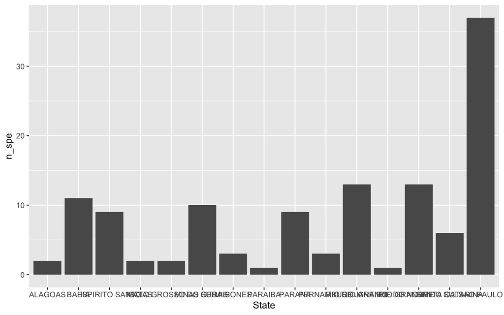

```r
ggplot(data = butterfly_state, aes(x = State, y = n_spe)) + geom_bar(stat = "identity")
```

En el gráfico resultante, vemos que es difícil leer los nombres en el axis horizontal. Para corregir esto,es posible utilizar la adición a el código siguiente:

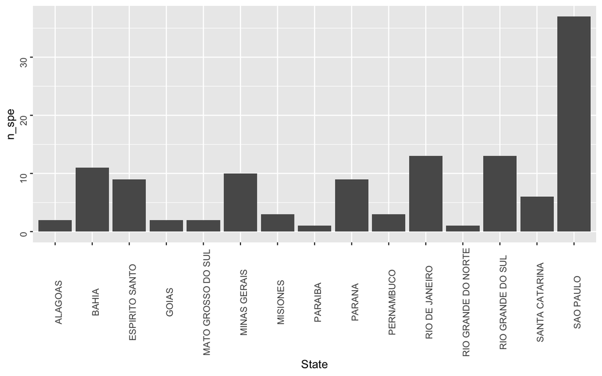

```r
 ggplot(data = butterfly_state, aes(x = State, y = n_spe)) + geom_bar(stat = "identity") +
  theme(axis.text = element_text(angle = 90))
```

**Ejercicio 4**

**Utilizando el estructura de datos, “polar”, crea un nuevo objeto, “high_temp”, utilizando la función `filter()`, para demonstrar todas las temperaturas mas grande que 23 degrado C. Después, utiliza la función, “True/False”, para ejecutar el comande previo. Pista: utiliza la función mutate() para crear una nueva columna**

**Haz clic aquí para solución!**

```r
str(polar)
```

```
## 'data.frame':    655 obs. of  144 variables:
##  $ ID..Consecutive.number.of.transec....                  : int  1 2 3 4 5 6 7 8 9 10 ...
##  $ Date.Time..Starting.time..UTC..of.30.min....           : chr  "2012-04-11T13:30" "2012-04-11T14:00" "2012-04-11T14:30" "2012-04-11T15:00" ...
##  $ Latitude..Mid.latitude.of.30.min.transe....            : num  -51.5 -51.4 -51.3 -51.3 -51.2 ...
##  $ Longitude..Mid.longitude.of.30.min.trans....           : num  -66.9 -66.8 -66.7 -66.7 -66.6 ...
##  $ Bathy.depth..m...Mid.mean.water.depth.of.30.mi....     : int  108 115 124 117 123 121 122 121 122 NA ...
##  $ Speed..kn...Average.speed.of.the.vessel.d....          : num  8.8 9.3 9.4 9.2 5.7 9.7 9.3 9.2 9.9 9.8 ...
##  $ Distance..km...Distance.covered.during.30.mi....       : num  8.15 8.61 8.7 8.52 5.28 ...
##  $ Sal..Mid.mean.surface.salinity.of.....                 : num  32.9 32.9 32.9 32.9 33 ...
##  $ Temp...C...Mid.mean.surface.water.temper....           : num  8.39 8.26 8.5 8.48 8.21 ...
##  $ F.chl..µg.l...Mid.fluorescence.of.30.min.tr....        : num  5.35 5.49 5.49 5.75 5.8 6.01 6.14 6.5 6.61 6.91 ...
##  $ Zone..Zones..which.were.defined.on.....                : int  10 10 10 10 10 10 10 10 10 10 ...
##  $ E..chrysocome......Rockhopper.penguin.                 : int  0 0 0 0 0 0 0 0 0 0 ...
##  $ S..magellanicus......Magellanic.penguin.               : int  0 0 0 0 0 0 0 0 0 0 ...
##  $ Penguins......Penguin.sp..                             : int  0 0 0 0 0 0 0 0 0 0 ...
```

[output cut: 86 more lines]

```r
High_Temp <- filter(polar, Temp...C...Mid.mean.surface.water.temper.... >= 23)
High_Temp
```

| ID..Consecutive.number.of.transec…. | Date.Time..Starting.time..UTC..of.30.min…. | Latitude..Mid.latitude.of.30.min.transe…. | Longitude..Mid.longitude.of.30.min.trans…. | Bathy.depth..m…Mid.mean.water.depth.of.30.mi…. | Speed..kn…Average.speed.of.the.vessel.d…. | Distance..km…Distance.covered.during.30.mi…. | Sal..Mid.mean.surface.salinity.of….. | Temp…C…Mid.mean.surface.water.temper…. | F.chl..µg.l…Mid.fluorescence.of.30.min.tr…. | Zone..Zones..which.were.defined.on….. | E..chrysocome……Rockhopper.penguin. | S..magellanicus……Magellanic.penguin. | Penguins……Penguin.sp.. | T..melanophris……Black.browed.albatross. | T..cauta……Shy.albatross. | T..chlororhynchos……Atlantic.yellow.nosed.albatross. | D..exulans……Wandering.albatross. | D..dabbenena……Tristan.albatross. | Diomedea.sp…….Great.albatrosses.sp.. | D..epomophora……Southern.royal.albatross. | D..sanfordi……Northern.royal.albatross. | D..epomophora……including.Diomedea.sanfordi. | Albatrosses……Albatross.sp.. | M..giganteus……Southern.giant.petrel. | Macronectes.sp…….Giant.petrel.sp.. | F..glacialis……Northern.fulmar. | D..capense……Cape.petrel. | P..macroptera……Great.winged.petrel. | P..feae……Fea.s.petrel. | … |
| --- | --- | --- | --- | --- | --- | --- | --- | --- | --- | --- | --- | --- | --- | --- | --- | --- | --- | --- | --- | --- | --- | --- | --- | --- | --- | --- | --- | --- | --- | --- |
| 135 | 2012-04-18T14:00 | -31.42 | -39.43 | 4661 | 9.6 | 8.8896 | 35.8645 | 23.0101 | 3.02 | 9 | 0 | 0 | 0 | 0 | 0 | 0 | 0 | 0 | 0 | 0 | 0 | 0 | 0 | 0 | 0 | 0 | 0 | 0 | 0 | … |
| 143 | 2012-04-19T09:00 | -28.98 | -39.00 | 4330 | 10.6 | 9.8156 | 35.9608 | 24.6779 | 2.71 | 8 | 0 | 0 | 0 | 0 | 0 | 0 | 0 | 0 | 0 | 0 | 0 | 0 | 0 | 0 | 0 | 0 | 0 | 0 | 0 | … |
| 144 | 2012-04-19T09:30 | -28.89 | -39.00 | 4196 | 10.7 | 9.9082 | 36.1643 | 24.8572 | 2.82 | 8 | 0 | 0 | 0 | 0 | 0 | 3 | 0 | 0 | 0 | 0 | 0 | 0 | 0 | 0 | 0 | 0 | 0 | 0 | 0 | … |
| 145 | 2012-04-19T10:00 | -28.80 | -39.00 | 4068 | 10.6 | 9.8156 | 36.0574 | 24.7066 | 2.84 | 8 | 0 | 0 | 0 | 0 | 0 | 0 | 0 | 0 | 0 | 0 | 0 | 0 | 0 | 0 | 0 | 0 | 0 | 0 | 0 | … |
| 146 | 2012-04-19T10:30 | -28.70 | -39.00 | 3916 | 10.6 | 9.8156 | 35.9939 | 24.6284 | 2.84 | 8 | 0 | 0 | 0 | 0 | 0 | 0 | 0 | 0 | 0 | 0 | 0 | 0 | 0 | 0 | 0 | 0 | 0 | 0 | 0 | … |

```r
polar %>% mutate(temp_high_23 = ifelse(Temp...C...Mid.mean.surface.water.temper.... >= 23, TRUE, FALSE)) %>%
  filter(temp_high_23 ==TRUE) ##creating a new column that shows which temp are greater than 23 - makes a new column in order to do the same thing as the first code
```

[output not shown]

**Ejercicio 5**

**En este ejercicio, vas a manipular el estructura de datos, “parrot”.**

**a) Elimina los especies que nunca estan registrados y también elimina información que no vamos a utilizar, “longitud” (Longitude), “latitud” (Latitude), y “tiempo en minutos” (Time..min.).**

**b) Reemplaza los puntos en los nombres de especies con guiones utilizando la función `str_replace()`.**

**c) Ahora que hemos manipulado el estructura de datos a nuestro gusto, crea un “gráfico de barras” (Bar graph) visualizando la suma de abundancia para cada especies.**

**Haz clic aquí para solución!**

```r
parrot <- read.csv("parrot.csv")
head(parrot)
```

| Longitude | Latitude | Code | Time..min. | Date.Time | A..amazonica…. | A..autumnalis…. | A..barbadensis…. | A..dufresniana…. | A..farinosa…. | A..festiva…. | A..mercenaria…. | A..ochrocephala…. |
| --- | --- | --- | --- | --- | --- | --- | --- | --- | --- | --- | --- | --- |
| -72.54740 | 10.31623 | NM05 | 3 | 2010-03-15T11:13 | 0 | 0 | 0 | 0 | 0 | 0 | 0 | 0 |
| -72.54267 | 10.31252 | NM05 | 3 | 2010-03-15T11:06 | 0 | 0 | 0 | 0 | 0 | 0 | 0 | 0 |
| -72.53757 | 10.31035 | NM05 | 3 | 2010-03-15T10:59 | 0 | 0 | 0 | 0 | 0 | 0 | 0 | 0 |
| -72.53145 | 10.30940 | NM05 | 3 | 2010-03-15T10:54 | 0 | 0 | 0 | 0 | 0 | 0 | 0 | 0 |
| -72.52523 | 10.30667 | NM05 | 3 | 2010-03-15T10:46 | 0 | 0 | 0 | 0 | 0 | 0 | 0 | 0 |

```r
parrot_clean_wrangle <- parrot %>%
  ## remove species that never appear
  select(-`A..dufresniana....`, -`A..festiva....`, -`A..autumnalis....`, -`A..mercenaria....`) %>%
  ## remove extra information that we are not going to use
  select(-Longitude, -Latitude, -`Time..min.`) %>%
  ## rename code for site to make it more intuitive
  rename(site = Code)

colnames(parrot_clean_wrangle) <- str_replace(str_remove_all(colnames(parrot_clean_wrangle), "\\.\\.\\.\\."), "\\.\\.", "_")

head(parrot_clean_wrangle)
```

| site | Date.Time | A_amazonica | A_barbadensis | A_farinosa | A_ochrocephala |
| --- | --- | --- | --- | --- | --- |
| NM05 | 2010-03-15T11:13 | 0 | 0 | 0 | 0 |
| NM05 | 2010-03-15T11:06 | 0 | 0 | 0 | 0 |
| NM05 | 2010-03-15T10:59 | 0 | 0 | 0 | 0 |
| NM05 | 2010-03-15T10:54 | 0 | 0 | 0 | 0 |
| NM05 | 2010-03-15T10:46 | 0 | 0 | 0 | 0 |

```r
##filters everything using "or" - |
parrot_clean_filter <- parrot_clean_wrangle %>% filter((A_amazonica != 0 | A_barbadensis != 0 | A_farinosa != 0 | A_ochrocephala != 0))
```

```r
parrot_clean_filter %>%
   pivot_longer(names_to = "Species", values_to = "Abundance", A_amazonica:A_ochrocephala) %>%
  group_by(Species) %>%
  summarise(total_abundance = sum(Abundance)) %>%
  ggplot(aes(x = Species, y = total_abundance)) + geom_bar(stat = "identity")
```

[output not shown]

**Ejercicio 6**

**En este ejercicio, utiliza el estructura de datos original, “butterfly_genus_site, para cambiar el estructura a forma ancho y asignar la nueva estructura al nombre”butterfly_wide”. Después, cambia la estructure nueva, “butterfly_wide” de reverso a forma larga y asigna lo a un objeto, “butterfly_long”, para practicar utilizando estas tipas de funciónes.**

**Haz clic aquí para solución!**

```r
butterfly_wide <- pivot_wider(butterfly_genus_site, names_from = Genus, values_from = n_spe)

butterfly_wide <- pivot_wider(butterfly_genus_site, names_from = Genus, values_from = n_spe, values_fill = 0)

butterfly_long <- pivot_longer(butterfly_wide, values_to = 'number_species', names_to = "genus", -sites_ID)

butterfly_long <- pivot_longer(butterfly_genus_site )
```